# Workshop: environment test notebook

For testing an early version of the environment that we'll use for the workshop, you will need to import it. There are two primary ways to import/create an environment. Here, I will focus on the graphical user interface instead of the command line.

## GUI: import environment

1. Open the Anaconda Navigator app.
2. On the left, click Environment.
3. At the bottom of the resulting main window, click Import.
4. In the resulting popup, click the folder icon, navigate to the `environment.yml` file, and click Open.
5. Back in the import popup, the environment name should be filled in automatically from the file, `workshop` in this case. Click Import.
6. Wait for the packages for the environment to be downloaded and installed. This could take a few minutes.

## GUI: run test notebook

1. Open the Anaconda Navigator app.
2. Make sure that the app is on the Home tab on the left.
3. At the top in the Applications on dropdown box, make sure `workshop` is selected.
4. Find JupyterLab in the main window and click its Launch button.
5. Wait for a webpage to appear (quickly) in your web browser with the JupyterLab interface.
6. In the file browser on the left side of JupyterLab interface, navigate to the notebook file and open it by double-clicking the icon to the left of the file name.
7. At the top of the JupyterLab interface, click the Kernel menu and select "Restart Kernel and Run All Cells..."
8. In the resulting popup, click Restart.
9. Wait for the notebook to execute, and verify that there are no errors.

```python
import pandas as pd
import numpy as np
from textblob import TextBlob

from keras.models import Sequential
from keras.layers import Dense
```

# pandas

```python
data1 = pd.DataFrame(np.random.rand(200, 4), columns=[l for l in 'ABCD'])
data2 = pd.DataFrame(np.random.rand(200, 4), columns=[l for l in 'ABCD'])
```

```python
data1.head()
```

|  | A | B | C | D |
| --- | --- | --- | --- | --- |
| 0 | 0.762944 | 0.304976 | 0.373977 | 0.332725 |
| 1 | 0.851833 | 0.431951 | 0.838820 | 0.098913 |
| 2 | 0.340837 | 0.079770 | 0.320549 | 0.869864 |
| 3 | 0.288180 | 0.429324 | 0.630384 | 0.458718 |
| 4 | 0.019641 | 0.421082 | 0.803037 | 0.176504 |

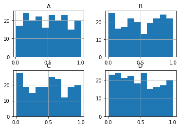

```python
%matplotlib inline
data1.hist();
```

## TextBlob

```python
string1 = 'Text analysis is a lot of fun!'
TextBlob(string1).sentiment
```

```
Sentiment(polarity=0.375, subjectivity=0.2)
```

```python
string2 = 'It is not scary.'
TextBlob(string2).sentiment
```

```
Sentiment(polarity=0.25, subjectivity=1.0)
```

```python
string3 = 'Manual coding is the worst.'
TextBlob(string3).sentiment
```

```
Sentiment(polarity=-1.0, subjectivity=1.0)
```

```python
string4 = 'Manual coding is kind of the worst.'
TextBlob(string4).sentiment
```

```
Sentiment(polarity=-0.2, subjectivity=0.95)
```

```python
strings = ' '.join([string1, string2, string3, string4])
TextBlob(strings).sentiment
```

```
Sentiment(polarity=-0.155, subjectivity=0.82)
```

## Keras

Note that we're training a tiny model on random data, so we're not actually expecting anything here other than surfacing errors if something isn't working.

```python
model = Sequential()

model.add(Dense(units=16, activation='relu', input_dim=3))
model.add(Dense(units=1, activation='softmax'))

model.compile(loss='mse',
              optimizer='rmsprop',
              metrics=['accuracy'])

model.fit(data1[['B', 'C', 'D']], data1['A'], epochs=10, batch_size=50);
```